# OLS Regression II

# Agenda

- Predictions
- Interactions

# Learning objectives

By the end of the lecture, you will be able to …

- Generate and communicate predictions from OLS regression models.
- Estimate, visualize, and communicate interaction effects in OLS regression models.

# Code-along 08

Download and open [code-along-08.qmd](https://www.dropbox.com/scl/fi/tapnw643rp19don4z38qe/code-along-08.qmd?rlkey=654vq3lssf7zy4266veaqhway&st=vi14yolc&dl=1)

## Packages

Load the standard packages.

```r
library(tidyverse)
library(haven) # not core tidyverse
library(gssr)
library(gssrdoc)
library(summarytools)
library(gtsummary)
library(modelbased)
```

## Load your data

```r
# Load GSS 2024
gss24 <- gss_get_yr(2024)
```

## Variables

- `realrinc` R’s income in constant $
- `age` Age of respondent
- `educ` Respondents highest edu credit
- `hrs1` How many hours did you work last week
- `sex` Respondents sex
- `marital` R’s marital status

Make a df with only the (pretty) categorical and continuous variables we’ll analyze.

```r
# Categorical Variables
my_cat <- gss24 |>
  select(id, sex, marital) |>
  zap_missing() |>
  mutate(
    sex = as_factor(sex),
    marital = as_factor(marital)) |>
  droplevels()

# Continuous Variables
my_con <- gss24 |>
  select(id, age, educ, hrs1, realrinc) |>
  mutate(
    age = as.numeric(age),
    educ = as.numeric(educ),
    hrs1 = as.numeric(hrs1),
    realrinc = as.numeric(realrinc))

# Combine the two dataframes
my_data <- full_join(my_cat, my_con, by = c("id")) |>
  drop_na() |>
  mutate(
    marital = recode(
      marital,
      "married"       = "Married",
      "never married" = "Never married",
      "widowed"       = "Div/Wid/Sep",
      "divorced"      = "Div/Wid/Sep",
      "separated"     = "Div/Wid/Sep"),
    marital = factor(
      marital,
      levels = c("Never married", "Div/Wid/Sep", "Married"))
  )

remove(my_con) # clean up the Environment
remove(my_cat)
```

# Predictions

OLS Regression Predicting Annual Income

| **Characteristic** | **Beta**<sup>1</sup> | **SE** |
| --- | --- | --- |
| (Intercept) | -34,540*** | 3,230 |
| educ | 2,845*** | 187 |
| hrs1 | 424*** | 38.0 |
| Women | -6,544*** | 1,018 |
| Marital status (ref. = never married) |  |  |
| Div/Wid/Sep | 5,512*** | 1,402 |
| Married | 11,182*** | 1,124 |
| R² | 0.243 |  |
| No. Obs. | 1,823 |  |

<sup>1</sup> *p<0.05; **p<0.01;*** p<0.001

## Typical-person predictions

**What does “holding other variables constant” mean?**

For a typical-person prediction, we set:

- continuous variables to their means
- categorical variables to the category we want to describe (e.g., a never-married woman)

```r
mean(my_data$educ)
```

```
[1] 14.78332
```

```r
mean(my_data$hrs1)
```

```
[1] 39.79046
```

Education = 14.78  
Hours worked = 39.79

## Typical-person predictions

```r
preds <- estimate_means(
  model,
  estimate = "typical")

preds
```

```
Estimated Marginal Means

sex    | marital       |     Mean |      SE |               95% CI | t(1817)
----------------------------------------------------------------------------
male   | Never married | 24386.18 |  969.85 | [22484.05, 26288.32] |   25.14
female | Never married | 17842.68 |  973.15 | [15934.08, 19751.29] |   18.34
male   | Div/Wid/Sep   | 29897.76 | 1295.96 | [27356.03, 32439.50] |   23.07
female | Div/Wid/Sep   | 23354.26 | 1188.22 | [21023.84, 25684.68] |   19.65
male   | Married       | 35567.77 |  874.88 | [33851.90, 37283.64] |   40.65
female | Married       | 29024.27 |  941.75 | [27177.25, 30871.30] |   30.82

Variable predicted: realrinc
Predictors modulated: sex, marital
Predictors averaged: educ (15), hrs1 (40)
```

## Typical-person predictions

$$\operatorname{realrinc} = \alpha + \beta_{1}(\operatorname{educ}) + \beta_{2}(\operatorname{hrs1}) + \beta_{3}(\operatorname{sex}_{\operatorname{female}}) + \beta_{4}(\operatorname{marital}_{\operatorname{Div/Wid/Sep}}) + \beta_{5}(\operatorname{marital}_{\operatorname{Married}}) + \epsilon$$

Typical never-married man  
$\color{#18bc9c}{-34,540} \color{#3498db}{+(2,845_{educ}*14.8)}$ $\color{#fd7e14}{+(424_{hrs1}*39.79)}$

Typical never married woman  
$\color{#18bc9c}{-34,540} \color{#3498db}{+(2,845_{educ}*14.8)}$ $\color{#fd7e14}{+(424_{hrs1}*39.79)}$ $\color{#e74c3c}{-6,544_{female}}$

Typical married man  
$\color{#18bc9c}{-34,540} \color{#3498db}{+(2,845_{educ}*14.8)}$ $\color{#fd7e14}{+(424_{hrs1}*39.79)}$ $\color{#9b59b6}{+11,182_{married}}$

Typical divorced woman  
$\color{#18bc9c}{-34,540} \color{#3498db}{+(2,845_{educ}*14.8)}$ $\color{#fd7e14}{+(424_{hrs1}*39.79)}$ $\color{#e74c3c}{-6,544_{female}}$ $\color{#9b59b6}{+5,512_{divorced}}$

[figure not shown]

## Marginal Means

**Marginal means are adjusted group averages**.  
Calculated from the regression model by setting continuous predictors to their means and averaging over the categories of other categorical predictors, giving each category **equal weight**.

```r
marginal_means <- estimate_means(
  model,
  by = "sex",
  estimate = "typical")

marginal_means
```

```
Estimated Marginal Means

sex    |     Mean |     SE |               95% CI | t(1817)
-----------------------------------------------------------
male   | 29950.57 | 749.17 | [28481.24, 31419.90] |   39.98
female | 23407.07 | 717.41 | [22000.05, 24814.10] |   32.63

Variable predicted: realrinc
Predictors modulated: sex
Predictors averaged: educ (15), hrs1 (40), marital
```

## Average Adjusted Predictions (AAP)

**Average adjusted predictions are adjusted population averages.**  
Calculated by setting everyone in the data to each group in turn (first all male, then all female) while keeping their other characteristics as observed, then averaging the predictions. Categories are weighted by **how common they are** in the data.

```r
aap <- estimate_means(
  model,
  by = "sex",
  estimate = "population")

aap
```

```
Average Counterfactual Predictions

sex    |     Mean |     SE |               95% CI | t(1817)
-----------------------------------------------------------
male   | 30409.31 | 709.70 | [29017.39, 31801.23] |   42.85
female | 23865.81 | 712.50 | [22468.40, 25263.22] |   33.50

Variable predicted: realrinc
Predictors modulated: sex
Predictors averaged: educ (15), hrs1 (40), marital
```

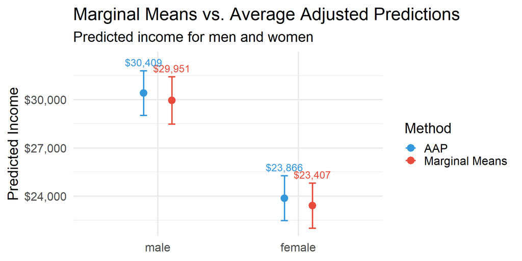

## 3 ways to hold variables constant:

|  | **Continuous predictors** | **Categorical predictors** |
| --- | --- | --- |
| **Typical-person prediction** *A hypothetical person* | Set to their means | Set to the category we choose (e.g., never-married woman) |
| **Marginal mean** *An adjusted group average* | Set to their means | Averaged over categories, equal weight for each |
| **Average adjusted prediction (AAP)** *An adjusted population average* | Kept at each person’s observed values | Everyone set to each group in turn, other characteristics as observed, then averaged |

## Example

| Method | Men | Women | Gap |
| --- | --- | --- | --- |
| Typical never-married | 24,386 | 17,843 | -6,544 |
| Marginal mean | 29,951 | 23,407 | -6,544 |
| AAP | 30,409 | 23,866 | -6,544 |

In this additive model, the gap between men and women is always the sex coefficient (-6,544).

The predicted income for each group changes because each method assumes a different mix of marital statuses.

## Group-Average Predictions

**What if we don’t hold anything constant?**  
Predict income for every person using their own characteristics, then average the predictions within each group.

```r
group_avg <- estimate_means(
  model,
  by = "sex",
  estimate = "average") |>
  mutate(method = "Group-average prediction")
```

| Method | Men | Women | Gap |
| --- | --- | --- | --- |
| Typical never-married | 24,386 | 17,843 | -6,544 |
| Marginal mean | 29,951 | 23,407 | -6,544 |
| AAP | 30,409 | 23,866 | -6,544 |
| Group-average prediction | 31,195 | 23,074 | -8,121 |

## Same Idea, Different Names

| **In this lecture** | **You may also see** |
| --- | --- |
| **Typical-person prediction** | Adjusted prediction at the means (APM); adjusted prediction at representative values (APR); “holding other variables at their means” |
| **Marginal mean** | Estimated marginal mean (EMM); least-squares mean (LS-mean); predictions on a balanced grid |
| **Average adjusted prediction (AAP)** | Predictive margins; marginal standardization; average predicted values; “observed values approach” |
| **Group-average prediction** | Predictions averaged “over” groups; observed group means of predicted values |

## Same Idea, Different Code

| **Concept** | **modelbased** | **marginaleffects** | **Stata** |
| --- | --- | --- | --- |
| Typical person | `estimate = "typical"`, `by = c("sex", "marital")` | `predictions(newdata = datagrid(...))` | `margins sex, atmeans` |
| Marginal mean | `estimate = "typical"`, `by = "sex"` | `avg_predictions(newdata = "balanced", by = "sex")` | `margins sex, asbalanced` |
| AAP | `estimate = "population"` | `avg_predictions(variables = "sex")` | `margins sex` |
| Group-average | `estimate = "average"` | `avg_predictions(by = "sex")` | `margins, over(sex)` |

# Interactions

Interactions test a conditional relationship

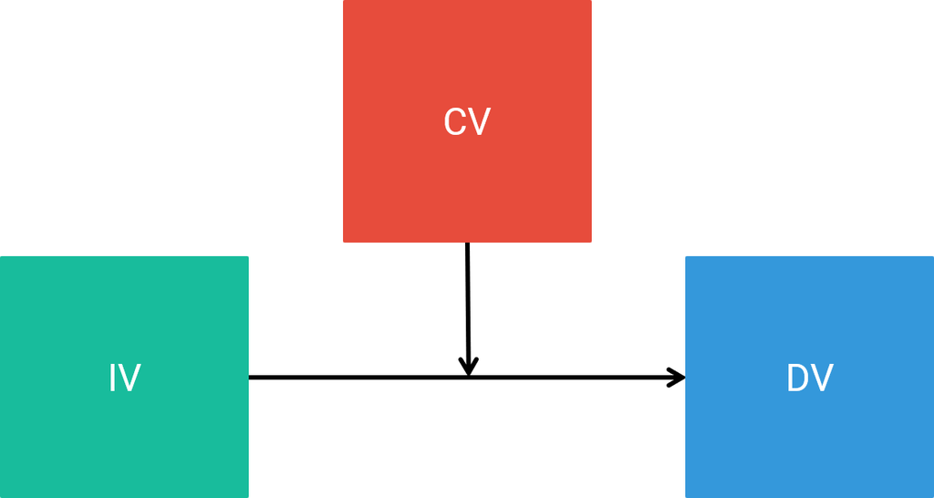

## Interactions

Without an interaction, the effect of $X_1$ on Y is $b_1$

$$\hat{Y} = b_0 + b_1X_1 + b_2X_2$$

With an interaction, the effect of $X_1$ on Y changes as $X_2$ changes  
Effect of $X_1$ on Y depends on the level of $X_2$

$$\hat{Y} = b_0 + b_1X_1 + b_2X_2 + {\color{#18bc9c}{b_3(X_1X_2)}}$$

## Categorical X Continuous

Does marital status modify the relationship between education and income?

```r
model_01 <- lm(formula = realrinc ~ educ + marital + age + hrs1 + sex, data = my_data)

p_inc <- estimate_means(
  model_01,
  by = c("marital", "educ = c(12:20)"),
  estimate = "population")

p_inc
```

## Categorical X Continuous

```
Average Counterfactual Predictions

marital       | educ |     Mean |      SE |               95% CI | t(1816)
--------------------------------------------------------------------------
Never married |   12 | 14172.36 | 1007.71 | [12195.96, 16148.75] |   14.06
Div/Wid/Sep   |   12 | 17892.87 | 1260.35 | [15420.97, 20364.76] |   14.20
Married       |   12 | 24168.27 |  957.92 | [22289.52, 26047.02] |   25.23
Never married |   13 | 16984.93 |  933.35 | [15154.37, 18815.49] |   18.20
Div/Wid/Sep   |   13 | 20705.44 | 1207.41 | [18337.38, 23073.49] |   17.15
Married       |   13 | 26980.84 |  856.43 | [25301.15, 28660.52] |   31.50
Never married |   14 | 19797.50 |  892.52 | [18047.03, 21547.96] |   22.18
Div/Wid/Sep   |   14 | 23518.01 | 1181.92 | [21199.94, 25836.07] |   19.90
Married       |   14 | 29793.41 |  786.81 | [28250.25, 31336.57] |   37.87
Never married |   15 | 22610.07 |  889.82 | [20864.88, 24355.25] |   25.41
Div/Wid/Sep   |   15 | 26330.58 | 1185.67 | [24005.16, 28655.99] |   22.21
Married       |   15 | 32605.98 |  757.93 | [31119.48, 34092.48] |   43.02
Never married |   16 | 25422.64 |  925.61 | [23607.27, 27238.01] |   27.47
Div/Wid/Sep   |   16 | 29143.15 | 1218.38 | [26753.58, 31532.72] |   23.92
Married       |   16 | 35418.55 |  774.34 | [33899.87, 36937.23] |   45.74
Never married |   17 | 28235.21 |  995.73 | [26282.31, 30188.11] |   28.36
Div/Wid/Sep   |   17 | 31955.72 | 1277.83 | [29449.55, 34461.89] |   25.01
Married       |   17 | 38231.12 |  833.37 | [36596.66, 39865.58] |   45.88
Never married |   18 | 31047.78 | 1093.61 | [28902.92, 33192.64] |   28.39
Div/Wid/Sep   |   18 | 34768.29 | 1360.52 | [32099.94, 37436.64] |   25.56
Married       |   18 | 41043.69 |  926.92 | [39225.75, 42861.63] |   44.28
Never married |   19 | 33860.35 | 1212.54 | [31482.24, 36238.46] |   27.93
Div/Wid/Sep   |   19 | 37580.86 | 1462.51 | [34712.47, 40449.25] |   25.70
Married       |   19 | 43856.26 | 1045.76 | [41805.24, 45907.28] |   41.94
Never married |   20 | 36672.92 | 1346.95 | [34031.19, 39314.65] |   27.23
Div/Wid/Sep   |   20 | 40393.43 | 1580.08 | [37294.47, 43492.39] |   25.56
Married       |   20 | 46668.83 | 1182.29 | [44350.03, 48987.63] |   39.47

Variable predicted: realrinc
Predictors modulated: marital, educ = c(12:20)
Predictors averaged: age (44), hrs1 (40), sex
```

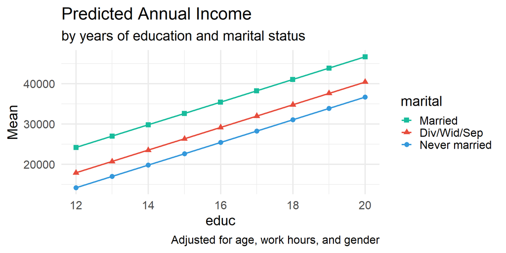

```r
model_02 <- lm(formula = realrinc ~ educ * marital
               + age + hrs1 + sex, data = my_data)

moderndive::get_regression_table(model_02)
```

| term | estimate | std_error | statistic | p_value | lower_ci | upper_ci |
| --- | --- | --- | --- | --- | --- | --- |
| intercept | -28,536.756 | 4,865.375 | -5.865 | 0.000 | -38,079.082 | -18,994.430 |
| educ | 2,085.885 | 303.424 | 6.874 | 0.000 | 1,490.788 | 2,680.982 |
| marital-Div/Wid/Sep | -4,415.821 | 7,577.829 | -0.583 | 0.560 | -19,278.009 | 10,446.367 |
| marital-Married | -11,610.242 | 6,303.987 | -1.842 | 0.066 | -23,974.079 | 753.595 |
| age | 114.684 | 40.959 | 2.800 | 0.005 | 34.352 | 195.016 |
| hrs1 | 445.561 | 38.160 | 11.676 | 0.000 | 370.720 | 520.402 |
| sex-female | -6,518.477 | 1,013.733 | -6.430 | 0.000 | -8,506.683 | -4,530.270 |
| educ:marital-Div/Wid/Sep | 559.883 | 511.105 | 1.095 | 0.273 | -442.533 | 1,562.299 |
| educ:marital-Married | 1,454.912 | 417.299 | 3.486 | 0.001 | 636.474 | 2,273.350 |

## Interpretation

**When interactions are included**:  
Interpret significance levels for interaction coefficients,  
NOT the significance levels for the main variables.

## Interpretation

| term | estimate | std_error | statistic | p_value | lower_ci | upper_ci |
| --- | --- | --- | --- | --- | --- | --- |
| intercept | -28,536.756 | 4,865.375 | -5.865 | 0.000 | -38,079.082 | -18,994.430 |
| educ | 2,085.885 | 303.424 | 6.874 | 0.000 | 1,490.788 | 2,680.982 |
| marital-Div/Wid/Sep | -4,415.821 | 7,577.829 | -0.583 | 0.560 | -19,278.009 | 10,446.367 |
| marital-Married | -11,610.242 | 6,303.987 | -1.842 | 0.066 | -23,974.079 | 753.595 |
| age | 114.684 | 40.959 | 2.800 | 0.005 | 34.352 | 195.016 |
| hrs1 | 445.561 | 38.160 | 11.676 | 0.000 | 370.720 | 520.402 |
| sex-female | -6,518.477 | 1,013.733 | -6.430 | 0.000 | -8,506.683 | -4,530.270 |
| educ:marital-Div/Wid/Sep | 559.883 | 511.105 | 1.095 | 0.273 | -442.533 | 1,562.299 |
| educ:marital-Married | 1,454.912 | 417.299 | 3.486 | 0.001 | 636.474 | 2,273.350 |

## Interpretation

The interaction tells you whether the effect of X becomes stronger or weaker for a particular group.

| Main Effect | Interaction | Result |
| --- | --- | --- |
| + | + | stronger effect |
| + | - | weaker effect |
| - | + | less negative effect |
| - | - | more negative effect |

Compare the sign of the main effect of the continuous variable to the sign of the interaction term. The interaction tells you whether the slope is steeper or flatter. (The sign of the group main effect tells you where the groups start.)

## Interpretation

```
Among never married people, every one year increase in education is associated with a $2,086 increase in income, holding other factors constant (p < .05).
```

```
At 0 years of education, married people report -$11,610 less income than never married people, adjusting for other model variables.
```

> Not a realistic effect of 0 education, so not meaningful.

```
The effect of education is $1,455 stronger for married respondents compared with never married respondents.
```

The main coefficients indicates the effect of that variable on the outcome when the other variable = 0

## Interpretation

```r
p_inc <- estimate_means(
  model_02,
  by = c("marital", "educ = c(12:20)"),
  estimate = "population")

p_inc
```

```
Average Counterfactual Predictions

marital       | educ |     Mean |      SE |               95% CI | t(1814)
--------------------------------------------------------------------------
Never married |   12 | 15995.38 | 1169.01 | [13702.64, 18288.13] |   13.68
Div/Wid/Sep   |   12 | 18298.16 | 1564.25 | [15230.23, 21366.08] |   11.70
Married       |   12 | 21844.08 | 1181.26 | [19527.32, 24160.85] |   18.49
Never married |   13 | 18081.27 |  997.13 | [16125.62, 20036.92] |   18.13
Div/Wid/Sep   |   13 | 20943.92 | 1329.39 | [18336.62, 23551.23] |   15.75
Married       |   13 | 25384.88 |  978.21 | [23466.35, 27303.41] |   25.95
Never married |   14 | 20167.15 |  897.83 | [18406.27, 21928.03] |   22.46
Div/Wid/Sep   |   14 | 23589.69 | 1194.76 | [21246.44, 25932.94] |   19.74
Married       |   14 | 28925.68 |  826.27 | [27305.13, 30546.23] |   35.01
Never married |   15 | 22253.04 |  895.57 | [20496.59, 24009.49] |   24.85
Div/Wid/Sep   |   15 | 26235.46 | 1194.72 | [23892.29, 28578.63] |   21.96
Married       |   15 | 32466.47 |  756.90 | [30981.98, 33950.96] |   42.89
Never married |   16 | 24338.92 |  991.02 | [22395.26, 26282.59] |   24.56
Div/Wid/Sep   |   16 | 28881.23 | 1329.29 | [26274.12, 31488.34] |   21.73
Married       |   16 | 36007.27 |  792.08 | [34453.78, 37560.76] |   45.46
Never married |   17 | 26424.81 | 1160.32 | [24149.11, 28700.51] |   22.77
Div/Wid/Sep   |   17 | 31526.99 | 1564.11 | [28459.34, 34594.65] |   20.16
Married       |   17 | 39548.07 |  919.90 | [37743.89, 41352.24] |   42.99
Never married |   18 | 28510.69 | 1376.48 | [25811.05, 31210.34] |   20.71
Div/Wid/Sep   |   18 | 34172.76 | 1861.62 | [30521.61, 37823.91] |   18.36
Married       |   18 | 43088.86 | 1108.77 | [40914.27, 45263.46] |   38.86
Never married |   19 | 30596.58 | 1620.86 | [27417.64, 33775.52] |   18.88
Div/Wid/Sep   |   19 | 36818.53 | 2196.49 | [32510.62, 41126.44] |   16.76
Married       |   19 | 46629.66 | 1332.98 | [44015.33, 49243.99] |   34.98
Never married |   20 | 32682.46 | 1882.49 | [28990.38, 36374.55] |   17.36
Div/Wid/Sep   |   20 | 39464.30 | 2554.07 | [34455.06, 44473.53] |   15.45
Married       |   20 | 50170.46 | 1577.54 | [47076.47, 53264.44] |   31.80

Variable predicted: realrinc
Predictors modulated: marital, educ = c(12:20)
Predictors averaged: age (44), hrs1 (40), sex
```

## Interpretation

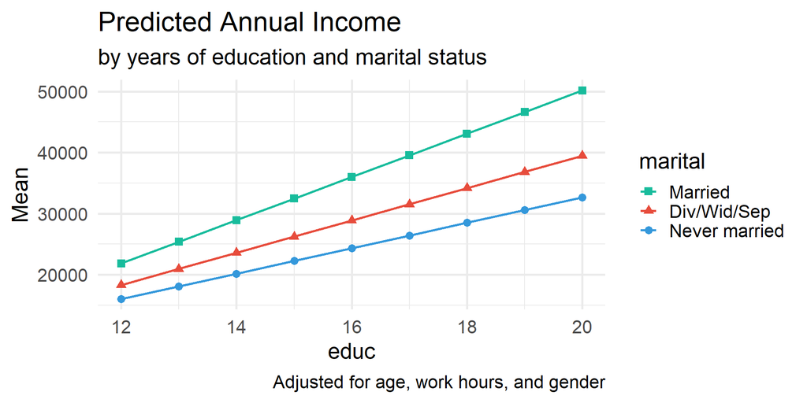

## Interpretation

You can predict the marginal effect of your continuous IV on your DV at different levels of your categorical IV:

| term | estimate | std_error | statistic | p_value | lower_ci | upper_ci |
| --- | --- | --- | --- | --- | --- | --- |
| intercept | -28,536.756 | 4,865.375 | -5.865 | 0.000 | -38,079.082 | -18,994.430 |
| educ | 2,085.885 | 303.424 | 6.874 | 0.000 | 1,490.788 | 2,680.982 |
| marital-Div/Wid/Sep | -4,415.821 | 7,577.829 | -0.583 | 0.560 | -19,278.009 | 10,446.367 |
| marital-Married | -11,610.242 | 6,303.987 | -1.842 | 0.066 | -23,974.079 | 753.595 |
| age | 114.684 | 40.959 | 2.800 | 0.005 | 34.352 | 195.016 |
| hrs1 | 445.561 | 38.160 | 11.676 | 0.000 | 370.720 | 520.402 |
| sex-female | -6,518.477 | 1,013.733 | -6.430 | 0.000 | -8,506.683 | -4,530.270 |
| educ:marital-Div/Wid/Sep | 559.883 | 511.105 | 1.095 | 0.273 | -442.533 | 1,562.299 |
| educ:marital-Married | 1,454.912 | 417.299 | 3.486 | 0.001 | 636.474 | 2,273.350 |

never married: $\color{#3498DB}{2086}$

div/wid/sep: $\color{#3498DB}{2086} + \color{#E74C3C}{560} = \color{#18BC9C}{2646}$

married: $\color{#3498DB}{2086} + \color{#E74C3C}{1455} = \color{#18BC9C}{3541}$

## `estimate_slopes()`

```r
estimate_slopes(
  model_02,
  trend = "educ",
  by = "marital"
)
```

```
Estimated Marginal Effects

marital       |   Slope |     SE |             95% CI | t(1814) |      p
------------------------------------------------------------------------
Never married | 2085.88 | 303.41 | [1490.81, 2680.96] |    6.87 | < .001
Div/Wid/Sep   | 2645.77 | 412.20 | [1837.32, 3454.21] |    6.42 | < .001
Married       | 3540.80 | 286.67 | [2978.56, 4103.04] |   12.35 | < .001

Marginal effects estimated for educ
Type of slope was dY/dX
```

## Interpretation

Among never married people, every one year increase in education is associated with a $2,086 rise in annual income, holding other factors constant.

Among div/wid/sep people, every one year increase in education is associated with a $2,646 rise in annual income, holding other factors constant.

Among married people, every one year increase in education is associated with a $3,541 rise in annual income, holding other factors constant.

## Conclusion

Does marital status modify the relationship between education and income?

The results are consistent with marital status modifying the relationship between education and income. The increase in income associated with each additional year of education is $1,455 greater among married individuals compared with never-married individuals (p = .001). The increase in income associated with each additional year of education is also $560 greater among previously married individuals than among never-married individuals, although this difference is not statistically significant.

## Categorical X Categorical

Does marital status modify the relationship between sex and income?

| term | estimate | std_error | statistic | p_value | lower_ci | upper_ci |
| --- | --- | --- | --- | --- | --- | --- |
| intercept | -38,545.024 | 3,548.663 | -10.862 | 0.000 | -45,504.915 | -31,585.134 |
| sex-female | -6,481.234 | 1,016.540 | -6.376 | 0.000 | -8,474.944 | -4,487.524 |
| marital-Div/Wid/Sep | 3,720.510 | 1,548.288 | 2.403 | 0.016 | 683.897 | 6,757.124 |
| marital-Married | 9,995.912 | 1,204.437 | 8.299 | 0.000 | 7,633.684 | 12,358.139 |
| age | 110.937 | 41.062 | 2.702 | 0.007 | 30.404 | 191.469 |
| hrs1 | 435.771 | 38.166 | 11.418 | 0.000 | 360.918 | 510.625 |
| educ | 2,812.571 | 186.769 | 15.059 | 0.000 | 2,446.266 | 3,178.875 |

| term | estimate | std_error | statistic | p_value | lower_ci | upper_ci |
| --- | --- | --- | --- | --- | --- | --- |
| intercept | -39,616.999 | 3,569.483 | -11.099 | 0.000 | -46,617.728 | -32,616.271 |
| sex-female | -3,133.293 | 1,646.863 | -1.903 | 0.057 | -6,363.241 | 96.655 |
| marital-Div/Wid/Sep | 6,175.199 | 2,291.522 | 2.695 | 0.007 | 1,680.900 | 10,669.498 |
| marital-Married | 12,861.277 | 1,630.622 | 7.887 | 0.000 | 9,663.183 | 16,059.370 |
| age | 101.802 | 41.174 | 2.472 | 0.014 | 21.048 | 182.555 |
| hrs1 | 424.668 | 38.348 | 11.074 | 0.000 | 349.457 | 499.880 |
| educ | 2,824.051 | 186.579 | 15.136 | 0.000 | 2,458.118 | 3,189.984 |
| sex-female:marital-Div/Wid/Sep | -4,365.909 | 2,855.077 | -1.529 | 0.126 | -9,965.493 | 1,233.675 |
| sex-female:marital-Married | -5,821.733 | 2,244.613 | -2.594 | 0.010 | -10,224.030 | -1,419.436 |

|  | Men | Women |
| --- | --- | --- |
| Never Married | 0 (ref) |  |
| Div/Wid/Sep |  |  |
| Married |  |  |

| term | estimate | std_error | statistic | p_value | lower_ci | upper_ci |
| --- | --- | --- | --- | --- | --- | --- |
| intercept | -39,616.999 | 3,569.483 | -11.099 | 0.000 | -46,617.728 | -32,616.271 |
| sex-female | -3,133.293 | 1,646.863 | -1.903 | 0.057 | -6,363.241 | 96.655 |
| marital-Div/Wid/Sep | 6,175.199 | 2,291.522 | 2.695 | 0.007 | 1,680.900 | 10,669.498 |
| marital-Married | 12,861.277 | 1,630.622 | 7.887 | 0.000 | 9,663.183 | 16,059.370 |
| age | 101.802 | 41.174 | 2.472 | 0.014 | 21.048 | 182.555 |
| hrs1 | 424.668 | 38.348 | 11.074 | 0.000 | 349.457 | 499.880 |
| educ | 2,824.051 | 186.579 | 15.136 | 0.000 | 2,458.118 | 3,189.984 |
| sex-female:marital-Div/Wid/Sep | -4,365.909 | 2,855.077 | -1.529 | 0.126 | -9,965.493 | 1,233.675 |
| sex-female:marital-Married | -5,821.733 | 2,244.613 | -2.594 | 0.010 | -10,224.030 | -1,419.436 |

|  | Men | Women |
| --- | --- | --- |
| Never Married | 0 (ref) | -3,133 |
| Div/Wid/Sep |  |  |
| Married |  |  |

| term | estimate | std_error | statistic | p_value | lower_ci | upper_ci |
| --- | --- | --- | --- | --- | --- | --- |
| intercept | -39,616.999 | 3,569.483 | -11.099 | 0.000 | -46,617.728 | -32,616.271 |
| sex-female | -3,133.293 | 1,646.863 | -1.903 | 0.057 | -6,363.241 | 96.655 |
| marital-Div/Wid/Sep | 6,175.199 | 2,291.522 | 2.695 | 0.007 | 1,680.900 | 10,669.498 |
| marital-Married | 12,861.277 | 1,630.622 | 7.887 | 0.000 | 9,663.183 | 16,059.370 |
| age | 101.802 | 41.174 | 2.472 | 0.014 | 21.048 | 182.555 |
| hrs1 | 424.668 | 38.348 | 11.074 | 0.000 | 349.457 | 499.880 |
| educ | 2,824.051 | 186.579 | 15.136 | 0.000 | 2,458.118 | 3,189.984 |
| sex-female:marital-Div/Wid/Sep | -4,365.909 | 2,855.077 | -1.529 | 0.126 | -9,965.493 | 1,233.675 |
| sex-female:marital-Married | -5,821.733 | 2,244.613 | -2.594 | 0.010 | -10,224.030 | -1,419.436 |

|  | Men | Women |
| --- | --- | --- |
| Never Married | 0 (ref) | -3,133 |
| Div/Wid/Sep | 6,175 |  |
| Married | 12,861 |  |

| term | estimate | std_error | statistic | p_value | lower_ci | upper_ci |
| --- | --- | --- | --- | --- | --- | --- |
| intercept | -39,616.999 | 3,569.483 | -11.099 | 0.000 | -46,617.728 | -32,616.271 |
| sex-female | -3,133.293 | 1,646.863 | -1.903 | 0.057 | -6,363.241 | 96.655 |
| marital-Div/Wid/Sep | 6,175.199 | 2,291.522 | 2.695 | 0.007 | 1,680.900 | 10,669.498 |
| marital-Married | 12,861.277 | 1,630.622 | 7.887 | 0.000 | 9,663.183 | 16,059.370 |
| age | 101.802 | 41.174 | 2.472 | 0.014 | 21.048 | 182.555 |
| hrs1 | 424.668 | 38.348 | 11.074 | 0.000 | 349.457 | 499.880 |
| educ | 2,824.051 | 186.579 | 15.136 | 0.000 | 2,458.118 | 3,189.984 |
| sex-female:marital-Div/Wid/Sep | -4,365.909 | 2,855.077 | -1.529 | 0.126 | -9,965.493 | 1,233.675 |
| sex-female:marital-Married | -5,821.733 | 2,244.613 | -2.594 | 0.010 | -10,224.030 | -1,419.436 |

|  | Men | Women |
| --- | --- | --- |
| Never Married | 0 (ref) | -3,133 |
| Div/Wid/Sep | 6,175 | -3,133 + 6,175 - 4,366 = -1,324 |
| Married | 12,861 |  |

| term | estimate | std_error | statistic | p_value | lower_ci | upper_ci |
| --- | --- | --- | --- | --- | --- | --- |
| intercept | -39,616.999 | 3,569.483 | -11.099 | 0.000 | -46,617.728 | -32,616.271 |
| sex-female | -3,133.293 | 1,646.863 | -1.903 | 0.057 | -6,363.241 | 96.655 |
| marital-Div/Wid/Sep | 6,175.199 | 2,291.522 | 2.695 | 0.007 | 1,680.900 | 10,669.498 |
| marital-Married | 12,861.277 | 1,630.622 | 7.887 | 0.000 | 9,663.183 | 16,059.370 |
| age | 101.802 | 41.174 | 2.472 | 0.014 | 21.048 | 182.555 |
| hrs1 | 424.668 | 38.348 | 11.074 | 0.000 | 349.457 | 499.880 |
| educ | 2,824.051 | 186.579 | 15.136 | 0.000 | 2,458.118 | 3,189.984 |
| sex-female:marital-Div/Wid/Sep | -4,365.909 | 2,855.077 | -1.529 | 0.126 | -9,965.493 | 1,233.675 |
| sex-female:marital-Married | -5,821.733 | 2,244.613 | -2.594 | 0.010 | -10,224.030 | -1,419.436 |

|  | Men | Women |
| --- | --- | --- |
| Never Married | 0 (ref) | -3,133 |
| Div/Wid/Sep | 6,175 | -3,133 + 6,175 - 4,366 = -1,324 |
| Married | 12,861 | -3,133 + 12,861 - 5,822 = 3,906 |

Among never married people, women’s income is $3,133 less than men, holding other model variables constant (p = .057).

Div/wid/sep men’s income is $6,175 more than never-married men, holding other model variables constant (p <. 01).

Married men’s income is $12,861 more than never-married men, holding other model variables constant (p < .001).

Compared with never-married individuals, being div/wid/sep is associated with a $4,366 smaller increase in income for women than for men, though the difference is not statistically significant.

The increase in income associated with being married compared with never married is $5,822 smaller for women than for men (p < .05).

## `estimate_means()`

```r
p_inc  <- estimate_means(
  model_03,
  by = c("marital", "sex"),
  estimate = "population")

p_inc
```

```
Average Counterfactual Predictions

marital       | sex    |     Mean |      SE |               95% CI | t(1814)
----------------------------------------------------------------------------
Never married | male   | 23484.99 | 1218.27 | [21095.63, 25874.34] |   19.28
Div/Wid/Sep   | male   | 29660.19 | 1880.87 | [25971.28, 33349.09] |   15.77
Married       | male   | 36346.26 | 1019.91 | [34345.95, 38346.58] |   35.64
Never married | female | 20351.69 | 1201.31 | [17995.60, 22707.78] |   16.94
Div/Wid/Sep   | female | 22160.98 | 1457.71 | [19302.02, 25019.95] |   15.20
Married       | female | 27391.24 | 1133.43 | [25168.27, 29614.21] |   24.17

Variable predicted: realrinc
Predictors modulated: marital, sex
Predictors averaged: age (44), hrs1 (40), educ (15)
```

## Interpretation

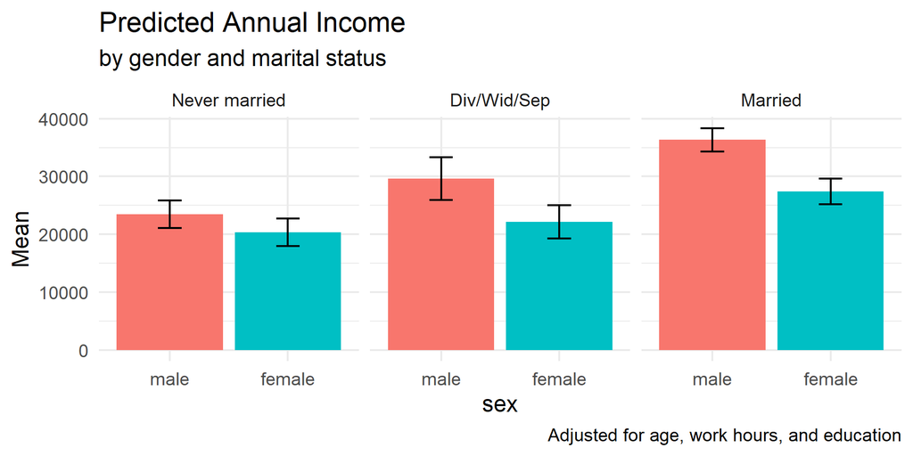

## `estimate_contrasts()`

```r
estimate_contrasts(
  model_03,
  contrast = "sex",
  by = "marital",
  estimate = "population")
```

```
Counterfactual Contrasts Analysis (G-computation)

Level1 | Level2 | marital       | Difference |      SE |                95% CI
------------------------------------------------------------------------------
female | male   | Never married |   -3133.29 | 1646.87 | [ -6363.25,    96.66]
female | male   | Div/Wid/Sep   |   -7499.20 | 2336.37 | [-12081.47, -2916.94]
female | male   | Married       |   -8955.03 | 1526.24 | [-11948.41, -5961.64]

Level1 | t(1814) |      p
-------------------------
female |   -1.90 |  0.057
female |   -3.21 |  0.001
female |   -5.87 | < .001

Variable predicted: realrinc
Predictors contrasted: sex
Predictors averaged: age (44), hrs1 (40), educ (15)
p-values are uncorrected.
```

## Conclusion

Does marital status modify the relationship between sex and income?

The results suggest that marital status modifies the relationship between sex and income. Among never-married respondents, women earned about $3,133 less than men (p = .057). Among married respondents, the gender gap was $5,822 larger, about $8,955 in total (p = .010). Among previously married respondents, the gender gap was $4,366 larger than among the never-married, about $7,499 in total, but this difference was not statistically significant (p = .126).

## Continuous X Continuous

Does education modify the relationship between age and income?

```r
model_04 <- lm(formula = realrinc ~ age + educ + hrs1 + sex + marital, data = my_data)

moderndive::get_regression_table(model_04) |>
  flextable()
```

| term | estimate | std_error | statistic | p_value | lower_ci | upper_ci |
| --- | --- | --- | --- | --- | --- | --- |
| intercept | -38,545.024 | 3,548.663 | -10.862 | 0.000 | -45,504.915 | -31,585.134 |
| age | 110.937 | 41.062 | 2.702 | 0.007 | 30.404 | 191.469 |
| educ | 2,812.571 | 186.769 | 15.059 | 0.000 | 2,446.266 | 3,178.875 |
| hrs1 | 435.771 | 38.166 | 11.418 | 0.000 | 360.918 | 510.625 |
| sex-female | -6,481.234 | 1,016.540 | -6.376 | 0.000 | -8,474.944 | -4,487.524 |
| marital-Div/Wid/Sep | 3,720.510 | 1,548.288 | 2.403 | 0.016 | 683.897 | 6,757.124 |
| marital-Married | 9,995.912 | 1,204.437 | 8.299 | 0.000 | 7,633.684 | 12,358.139 |

```r
model_04 <- lm(formula = realrinc ~ age * educ + hrs1 + sex + marital, data = my_data)

moderndive::get_regression_table(model_04)
```

| term | estimate | std_error | statistic | p_value | lower_ci | upper_ci |
| --- | --- | --- | --- | --- | --- | --- |
| intercept | -32,443.525 | 9,602.561 | -3.379 | 0.001 | -51,276.758 | -13,610.292 |
| age | -30.817 | 211.324 | -0.146 | 0.884 | -445.281 | 383.646 |
| educ | 2,390.116 | 645.403 | 3.703 | 0.000 | 1,124.304 | 3,655.927 |
| hrs1 | 437.098 | 38.221 | 11.436 | 0.000 | 362.136 | 512.059 |
| sex-female | -6,455.290 | 1,017.396 | -6.345 | 0.000 | -8,450.681 | -4,459.899 |
| marital-Div/Wid/Sep | 3,750.787 | 1,549.148 | 2.421 | 0.016 | 712.486 | 6,789.088 |
| marital-Married | 10,014.947 | 1,204.935 | 8.312 | 0.000 | 7,651.742 | 12,378.153 |
| age:educ | 9.642 | 14.100 | 0.684 | 0.494 | -18.012 | 37.297 |

When education is 0 years, every one-year increase in age predicts a $31 decrease in annual income, adjusting for other model variables.

> This interpretation is helpful only for people with no formal education.

When age is 0 years, every additional year of education predicts a $2,390 increase in annual income, adjusting for other model variables.

> This interpretation is helpful only for newborns, so it is not substantively meaningful.

For every one-year increase in age, the increase in income associated with an additional year of education is $9.6 greater, adjusting for other model variables, though it is not statistically significant.

## `estimate_means()`

```r
# age at selected values of educ
p_inc <- estimate_means(
  model_04,
  by = c(
    "educ = c(12, 14, 16)",
    "age = c(22, 24, 26, 28, 30, 32, 34, 36, 38, 40, 42, 44)"  ),
  estimate = "population"
)

p_inc |>
  head(5)
```

```
Average Counterfactual Predictions

educ | age |     Mean |      SE |               95% CI | t(1815)
----------------------------------------------------------------
12   |  22 | 17446.26 | 1370.16 | [14759.00, 20133.52] |   12.73
12   |  24 | 17616.03 | 1276.18 | [15113.10, 20118.97] |   13.80
12   |  26 | 17785.81 | 1185.17 | [15461.38, 20110.24] |   15.01
12   |  28 | 17955.59 | 1098.12 | [15801.88, 20109.30] |   16.35
12   |  30 | 18125.36 | 1015.89 | [16132.92, 20117.81] |   17.84

Variable predicted: realrinc
Predictors modulated: educ = c(12, 14, 16), age = c(22, 24, 26, 28, 30, 32, 34, 36, 38, 40, 42, 44)
Predictors averaged: hrs1 (40), sex, marital
```

## Interpretation

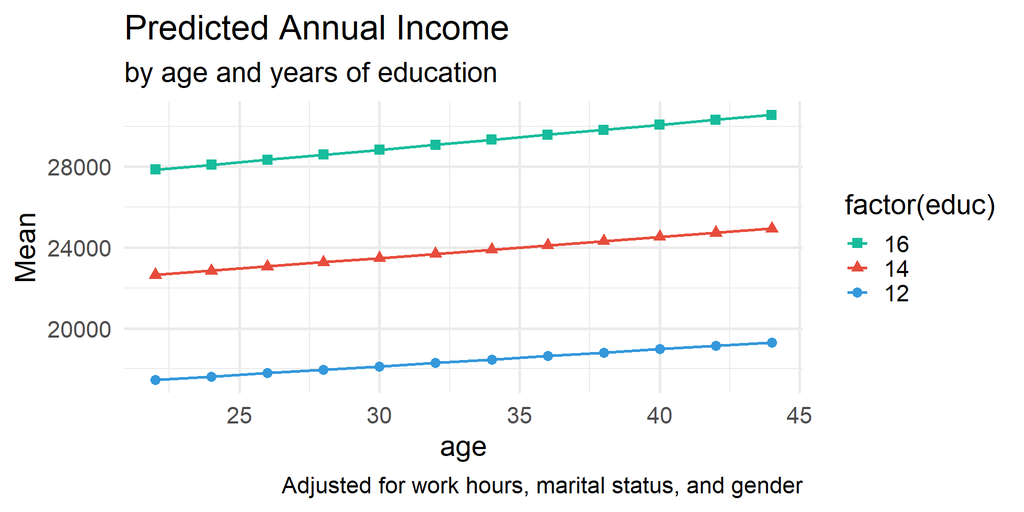

## Conclusion

Does the relationship between age and income depend on education?

Both age and education were independently and positively associated with income. Holding all other variables constant, each additional year of age is associated with an increase in annual income of approximately $111 (p < .01). Each additional year of education is associated with an increase in annual income of approximately $2,813 (p < .001).